# Aula 07

Leandro Carísio Fernandes

7/4/2022

## Áreas sob a curva normal

Utilize as funções **dnormal**, **dnormalp** e **pnorm** para resolver as questões a seguir.

## Questões

### 1) Suponha que *X* é normal com média igual a **8** e desvio-padrão igual a **5**. Encontre **P(*X* <= 8,6)**.

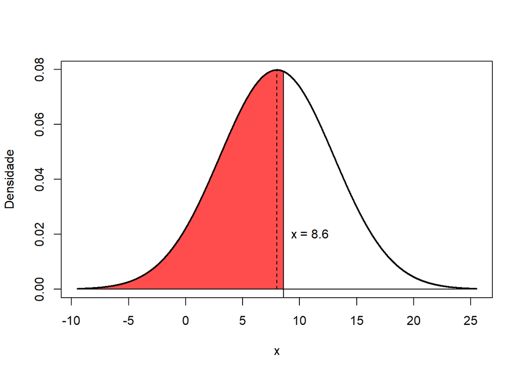

```r
pnorm(8.6, 8, 5)
```

```
## [1] 0.5477584
```

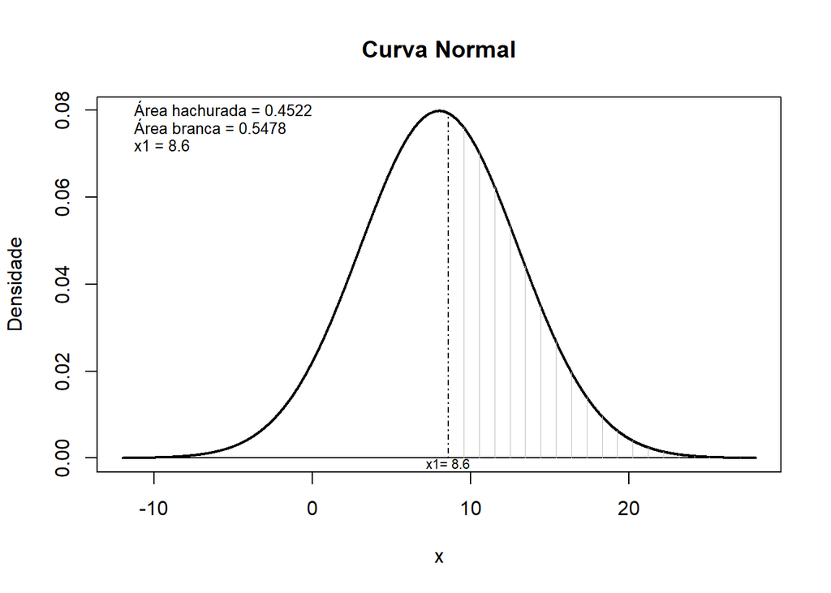

```r
dnormal(media=8, dp=5, x1=8.6, x2=NULL)
```

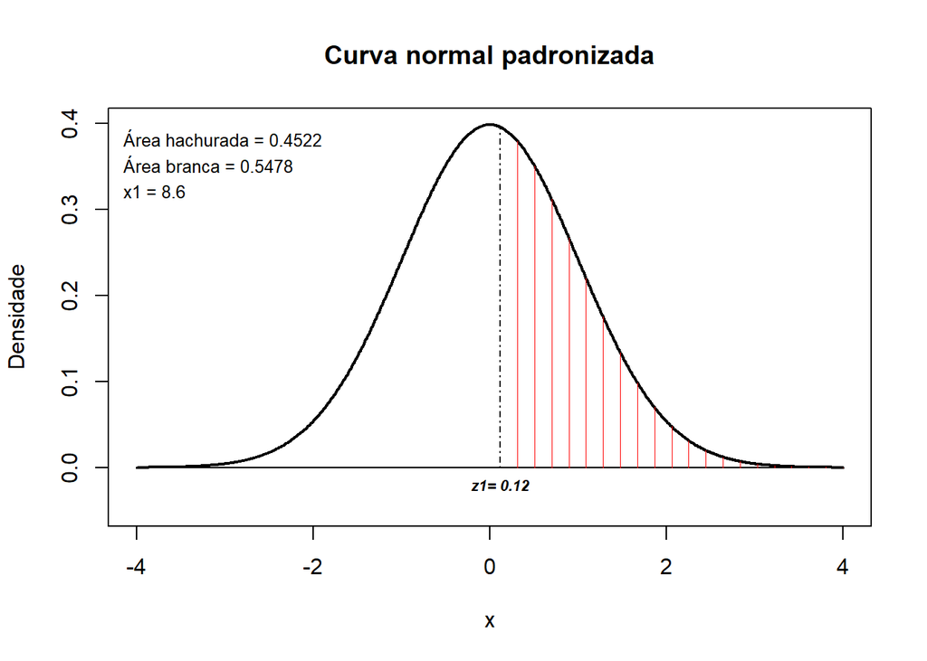

```r
dnormalp(media=8, dp=5, x1=8.6, x2=NULL)
```

### 2) Suponha que *X* é normal com média igual a **10** e desvio-padrão igual a **3**. Encontre **P(*X* > 8,6)**.

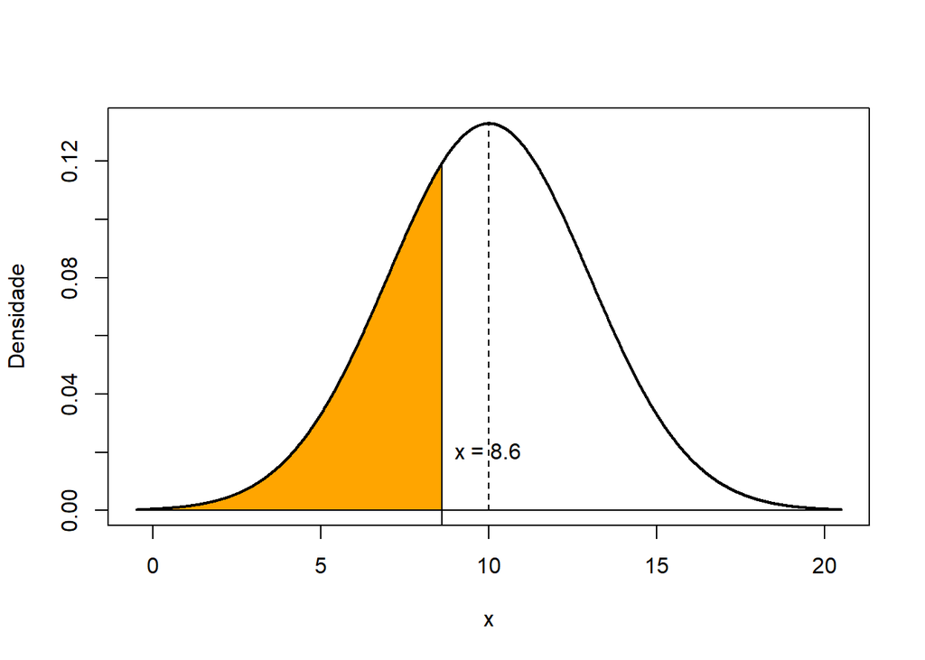

```r
1-pnorm(8.6, 10, 3)
```

```
## [1] 0.6796308
```

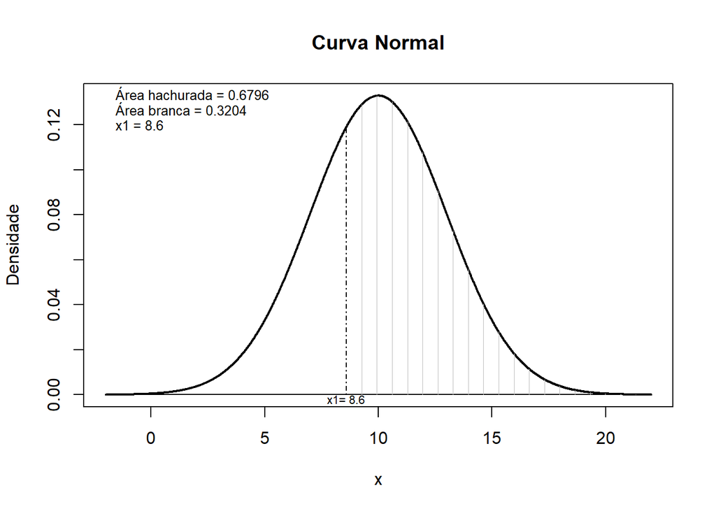

```r
dnormal(media=10, dp=3, x1=8.6, x2=NULL)
```

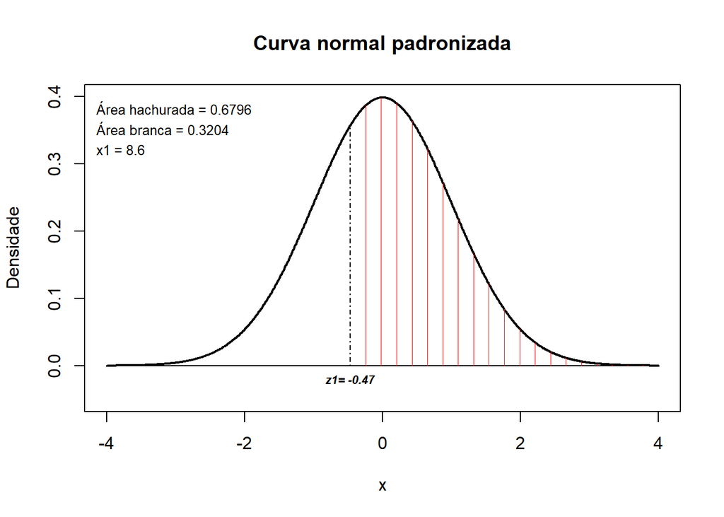

```r
dnormalp(media=10, dp=3, x1=8.6, x2=NULL)
```

### 3) Suponha que *X* é normal com média igual a **10** e desvio-padrão igual a **6**. Encontre **P(7,3 < *X* <= 12,4)**.

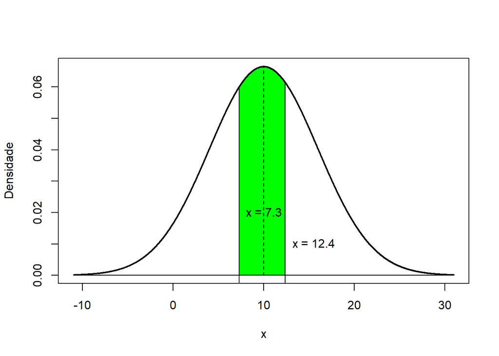

```r
pnorm(12.4, 10, 6) - pnorm(7.3, 10, 6)
```

```
## [1] 0.3290665
```

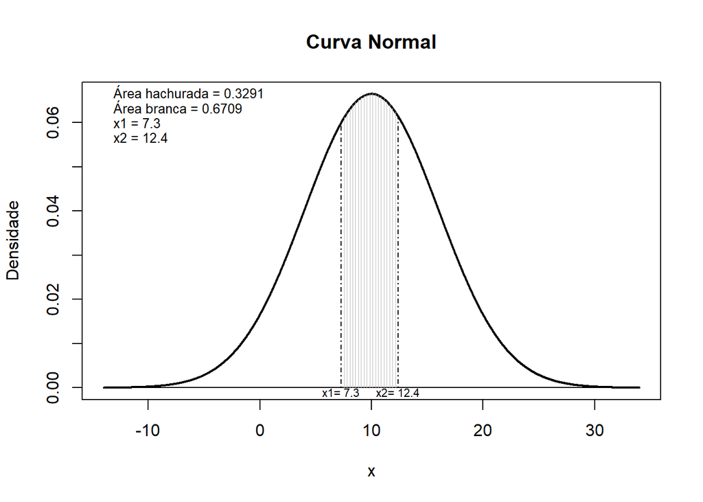

```r
dnormal(media=10, dp=6, x1=7.3, x2=12.4)
```

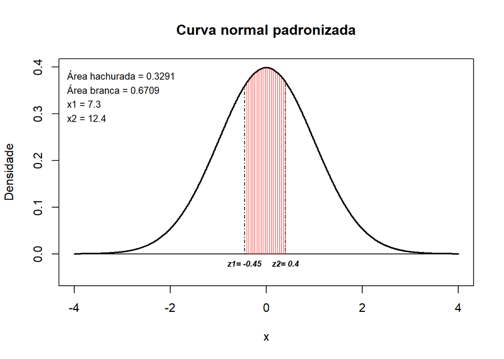

```r
dnormalp(media=10, dp=6, x1=7.3, x2=12.4)
```

### 4) Suponha que *X* é normal com média igual a **0** e desvio-padrão igual a **1**. Encontre **P(-1,96 < *X* <= 1,96)**.

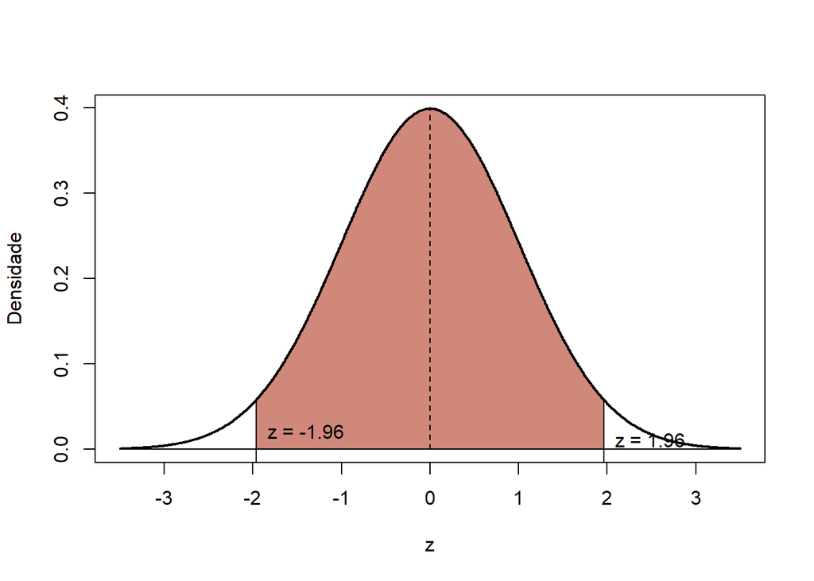

```r
pnorm(1.96) - pnorm(-1.96)
```

```
## [1] 0.9500042
```

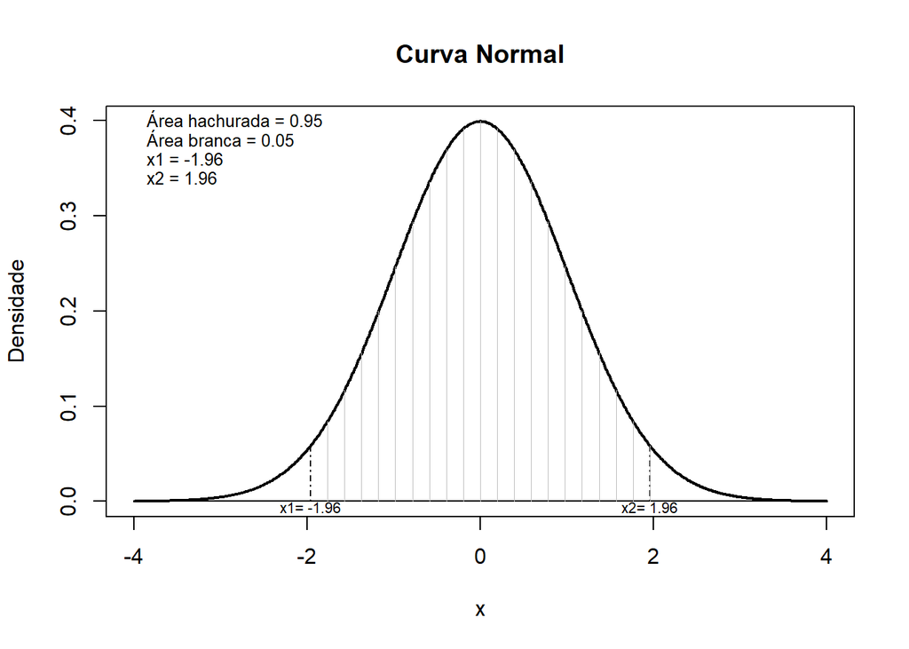

```r
dnormal(x1=-1.96, x2=1.96)
```

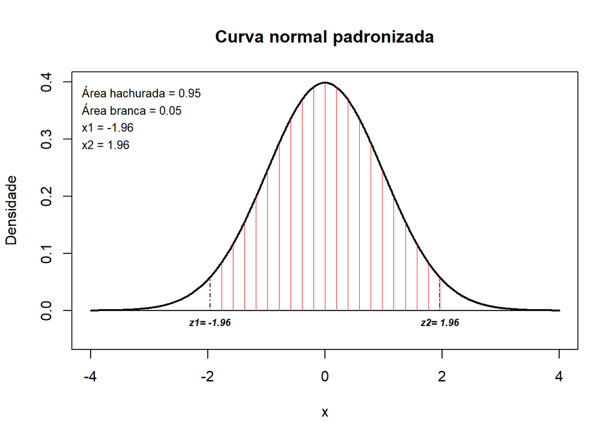

```r
dnormalp(x1=-1.96, x2=1.96)
```

### 5) Suponha que *X* é normal com média igual a **44.90** e desvio-padrão igual a **10.98**. Encontre **P(20 < *X* <= 40)**.

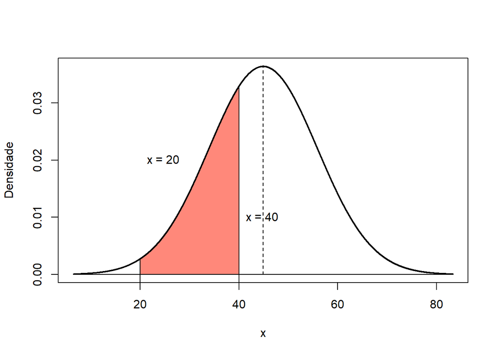

```r
pnorm(40, 44.9, 10.98) - pnorm(20, 44.9, 10.98)
```

```
## [1] 0.3160306
```

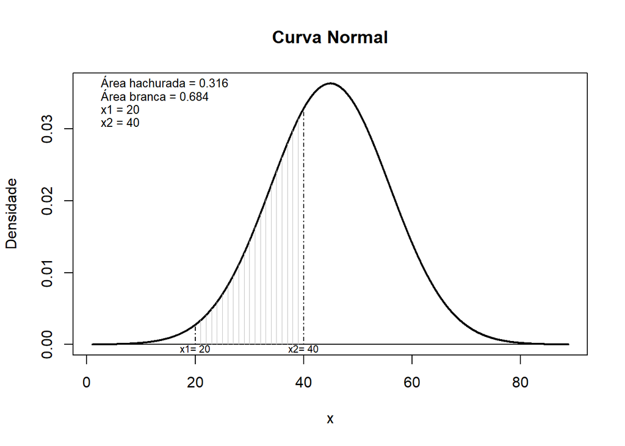

```r
dnormal(media=44.9, dp=10.98, x1=20, x2=40)
```

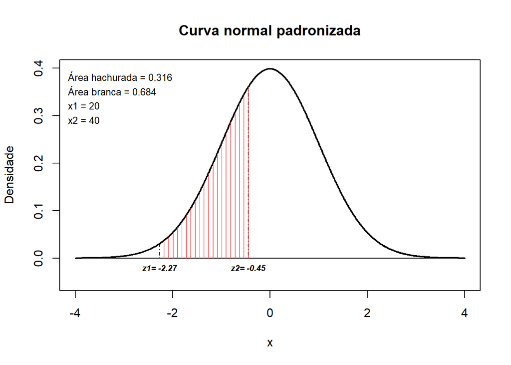

```r
dnormalp(media=44.9, dp=10.98, x1=20, x2=40)
```

### 6) Suponha que *X* é normal com média igual a **44.90** e desvio-padrão igual a **10.98**. Encontre **P(*X* > 60)**.

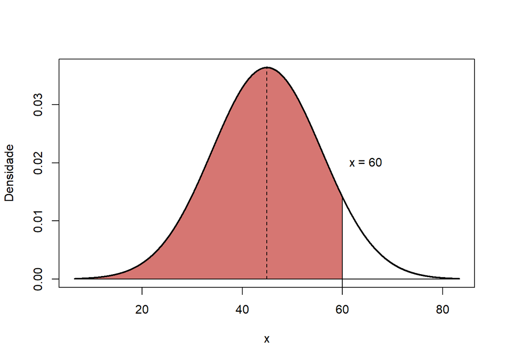

```r
1 - pnorm(60, 44.9, 10.98)
```

```
## [1] 0.08453043
```

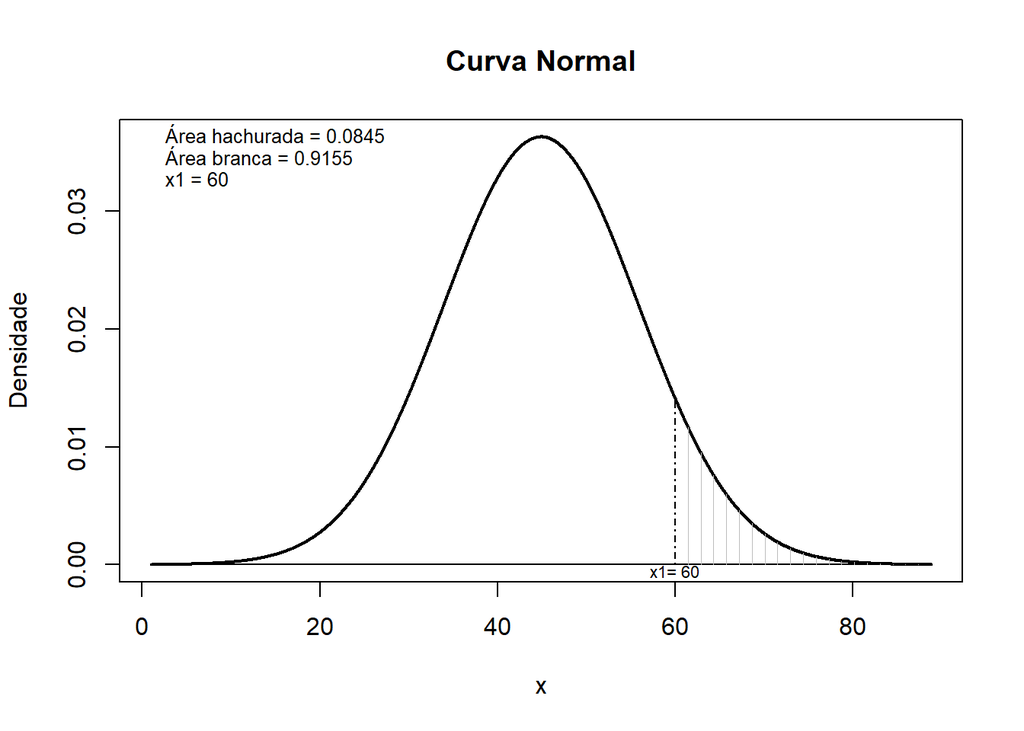

```r
dnormal(media=44.9, dp=10.98, x1=60, x2=NULL)
```

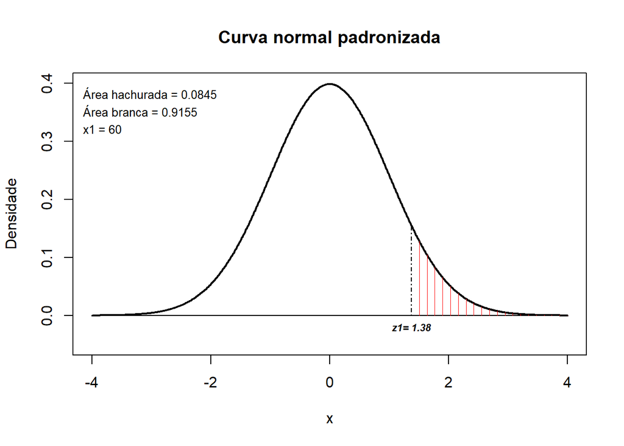

```r
dnormalp(media=44.9, dp=10.98, x1=60, x2=NULL)
```

### 7) Repita as questões 5 e 6 tomando por base o histograma a seguir:

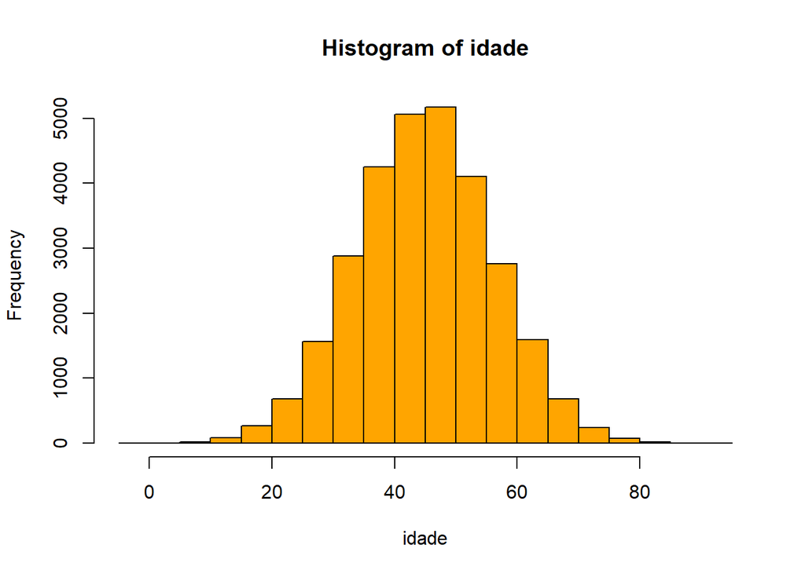

```r
sum(h$count[h$breaks >= 20 & h$breaks < 40]) / sum(h$count)
```

```
## [1] 0.3183748
```

```r
sum(h$count[h$breaks >= 60], na.rm=TRUE) / sum(h$count)
```

```
## [1] 0.08852804
```

### 8) O que pode ser dito sobre os resultados encontrados nas questões 5, 6 e 7?

O resultado é próximo quando a maior parte dos dados é considerada (questão 5). Entretanto, próximo das caudas, a divergência entre os dados e a distribuição normal é maior.

### 9) Suponha que *X* é normal com média igual a **500** e desvio-padrão igual a **40**. Encontre o valor aporximado de **P(*X* > 550)**.

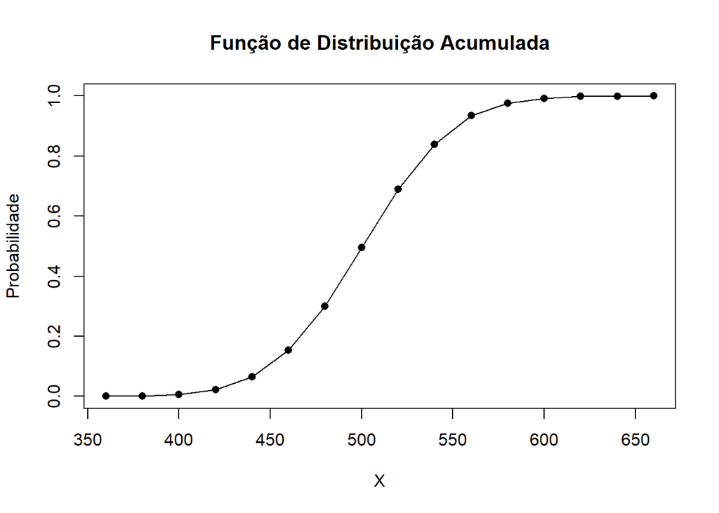

```r
1 - pnorm(550, 500, 40)
```

```
## [1] 0.1056498
```

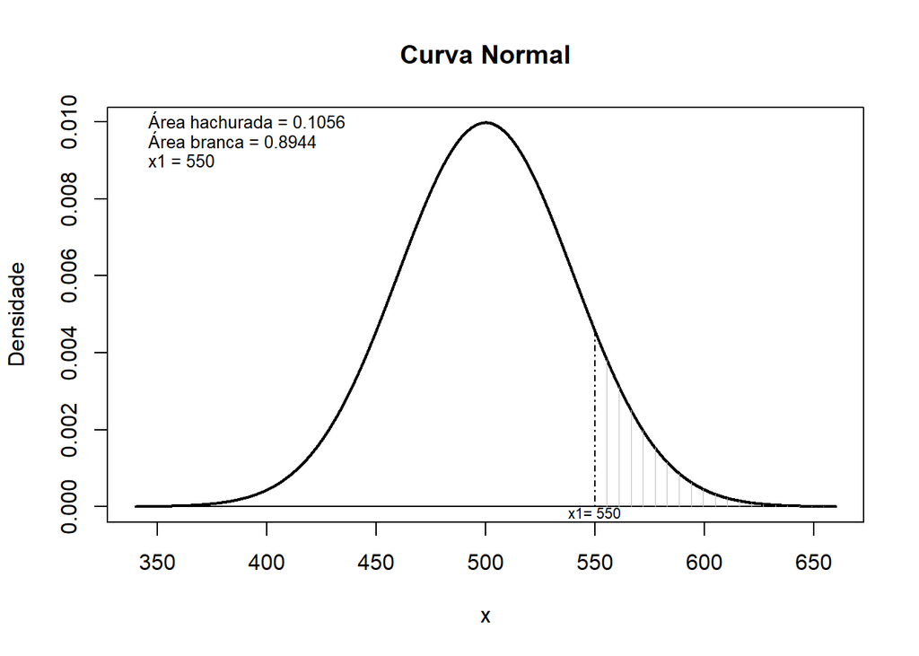

```r
dnormal(media=500, dp=40, x1=550, x2=NULL)
```

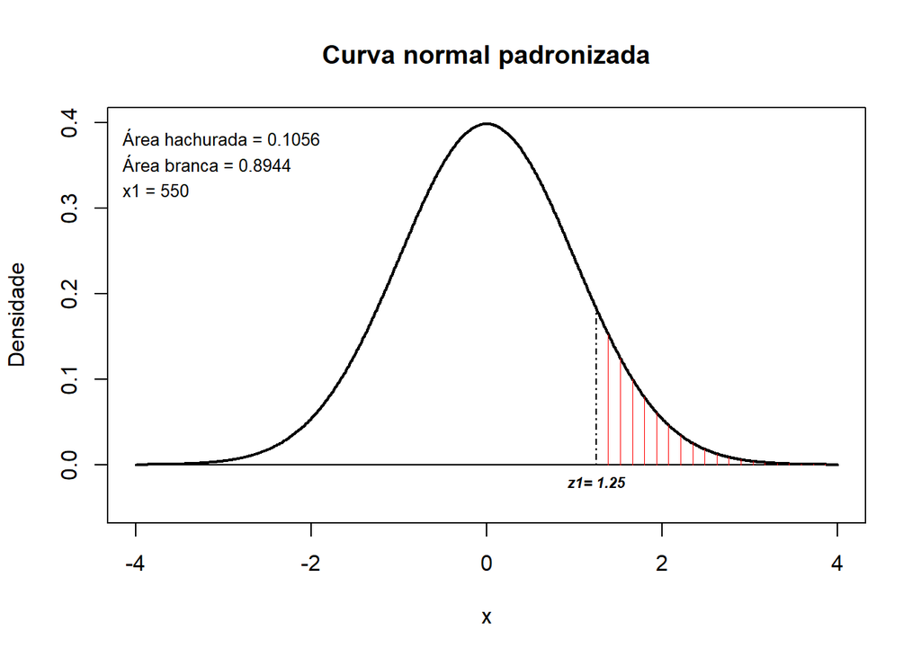

```r
dnormalp(media=500, dp=40, x1=550, x2=NULL)
```

### 10) Usando a Função de Distribuição Acumulada da questão anterior encontre o valor aporximado de **P(450 < *X* <= 550)**.

```r
h.cum[h$mid == 550] - h.cum[h$mid == 450]
```

```
## [1] 0.7812
```

```r
pnorm(550, 500, 40) - pnorm(450, 500, 40)
```

```
## [1] 0.7887005
```

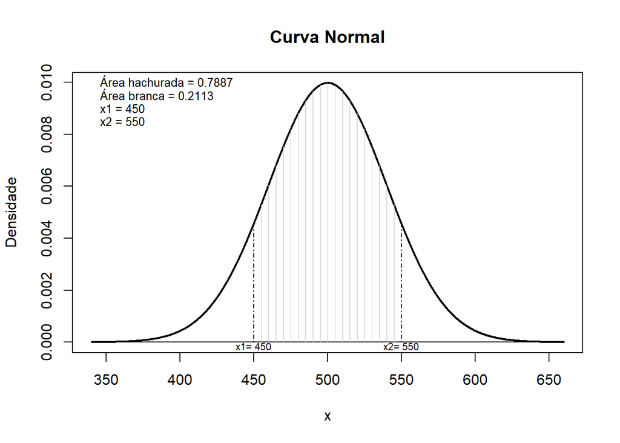

```r
dnormal(media=500, dp=40, x1=450, x2=550)
```

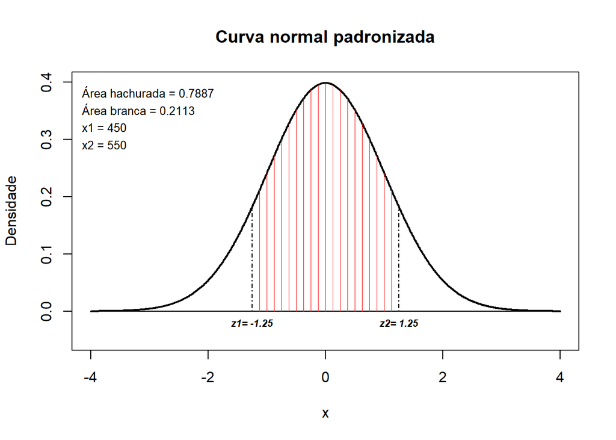

```r
dnormalp(media=500, dp=40, x1=450, x2=550)
```